# I. How to: RawData

The main objective of this document is to present the `RawData` class without going into too much detail, but presenting all the most important skills in order to understand the philosophy of `panaSKImg`.

For this howto it is important to have looked at the documentation related with the configuration parameters (see previous howto on this serie). It is not necessary to go into detail, but to know their existence, format and what they are used for.

## From the fits file to the RawData object

Here we will learn the representation of a fits file image within `pysimdamicm`. The data (i.e. the fits file image) is an instance of the `RawData` class, which represents our understanding of a CCD skipper image:

- a well defined number of columns and rows
- a fix number of skips
- a set of different well defined regions: an active area, and overscan and prescan regions in rows and columns
- a 2D array with the pixel-charge

### Configuration parameters for `RawData`

There are a large set of parameters to properly interpret the data input. All of them have been introduced for the Config howto, see `input` section of the configuration JSON file. In short, we would have

- `Ncols`
- `Nrows`
- `Nskips`
- `Npbin`
- `Nsbin`
- `axis_to_compress`
- `id_col_end`
- `id_col_start`
- `id_row_end`
- `id_row_start`
- `id_skip_end`
- `id_skip_start`
- `correct_leach_bug`
- `correct_polarity`

Some of the will be explained again throughout this document.

### Attributes of `RawData`

An instance of `RawData` will have several data members, the most important are:

#### `image` data member

This is created during instanciation containing all pixel charge values in a 3D array: (rows, cols, skips). The third dimensions for the skipper measurements. The image is therefore an array of dimension 3, where this thrid dimensiono corresponds to the k-th measure of the pixel in the position (y,x), i.e.

```
image[row,col,k]
```

#### `mask_image_active_region`

#### `mask_image_overscan_cols`, `mask_image_overscan_rows`

#### `mask_image_prescan_cols`, `mask_image_prescan_rows`

These are the 5 regions that any CCD image can have. Corresponds to the active region, the overscan in columns and rows (where no exposure time have been taken providing an snapshot of the baseline or pedestan of an image) and prescan in columns and rows (respectively).

These data members are created for method `RawData.prepare_data` being $\color{red}{\text{boolean arrays of dimension 2}}$ with shape number of rows per number of columns:

```
(Nrows,Ncols)
```

Note that all the data members has the same shape: they are just masks with True and False values, to define which pixels belongs to which region.

Along `panaSKImg` [masked arrays](https://numpy.org/doc/stable/reference/maskedarray.generic.html) will be used to select any of these regions. For instance, to compute the average pixel charge on the overscan on columns is as simple as

```
numpy.ma.array( RawData.image, mask=RawData.mask_image_overscan_cols).mean()
```

# Index

In this howto there are two main sections:

- Image as the instance of the RawData class
  - using the default configuration
  - using the configuration JSON file
- Learn a little bit more about the data members of RawData, and how to get the mask for each region

In this howto we will use the `CompressionSkipperProcess` class to get the averaged class and play a little bit with the mask for the serveral regions.

This howto will only be done from a Python Interpreter, meaning that we will not use `panaSKImg`, since the main objective is to learn a little about the data structure as an instance of `RawData`.

### Overview of this howto

1. Load all modules needed for this **howto**
2. Define which data to be used
3. Instanciation of `RawData`
   - using default configuration file
   - uisng a configuration json file
4. `image` data member
5. Use of `RawData` for already compressed images (averaged image)
6. Define CCCD regions: active area, overscan and prescan regions

### 0. Load all needed modules

```python
%matplotlib inline

import pysimdamicm as ccd

import numpy as np
from matplotlib import pyplot as plt
```

```
Welcome to JupyROOT 6.14/06
```

### 2. Define which data to be used

To access for instance to file number 25, we will use the function `format` as follows:

1. define the main path where raw data is sotred: `path_to_raw_data`
2. define an string with the pattern file name: `img_pattern_file_name`
3. access to the file name by the concatenation of both strings: `file_name`
4. use format to 'fill' the file number you are interested in

```python
# where raw data is
path_to_raw_data = "/media/ncastello/WORK/damicm/compton/calidaq_backup/DataTaking/Am241/Run_55"

# patter file name
img_pattern_file_name = "Image_Am241_Source_55_{}.fits"

# absolute path to the file name
file_name = "{}/{}".format(path_to_raw_data,img_pattern_file_name)

# see how looks like the concatenation
print( file_name )
```

```
/media/ncastello/WORK/damicm/compton/calidaq_backup/DataTaking/Am241/Run_55/Image_Am241_Source_55_{}.fits
```

Note that, this string contains the symbol {} which is used to tell `format` where its inputs should be placed.

See that with an example: the name for file number 25 can be build as follows

```python
print( "Name for file number 25 is: ", file_name.format(25) )
```

```
Name for file number 25 is:  /media/ncastello/WORK/damicm/compton/calidaq_backup/DataTaking/Am241/Run_55/Image_Am241_Source_55_25.fits
```

### 3. Instanciation of `RawData`

#### Loading a fits file using the `BuilderRawData` function

In this section we will learn how data from a fits file is structured as a `RawData` object.

The raw data file can be loaded by using the `BuilderRawData` function provided for `pysimdamicm.io.rawdata`. There are two parametrized constructors for this class:

1. with only the input fits file name (`file_name`)
2. with the input fits file name, and as a second argument, a dictionary to properly interpret the data recorded in the fits file (`file_config`).

With the former there is no information about how data is recorded on the fits file, and necessary information to properly interpret the data will be missed. Like for instance

- where overscan starts and end or the same for the active area,
- how many skips, and in which of the axis skips are taken
- data taken bugs that should be corrected before starting the data processing
- is the image inverted or not
- ...

All this parameters can be defined in a dictionary, and pass to the contructor as a second argument (we will learn how to do that later on).

A way to see how looks like the contructor is by typing

```python
help(ccd.io.rawdata.BuilderRawData)
```

```
Help on function BuilderRawData in module pysimdamicm.io.rawdata:

BuilderRawData(file_name, file_config=None)
```

### 3.1 Using the default configuration

Using the string `file_name` pointing to a fits file data, we can load this existing FITS file:

```python
rdata = ccd.io.rawdata.BuilderRawData( file_name.format(25) )
```

[output not shown]

[output cut: 46 more lines]

```
EXPSTART= 'Sun Nov 15 23:31:53 2020' / Exposure start time
RDSTRT  = 'Sun Nov 15 23:31:56 2020' / Readout start time
RDEND   = 'Sun Nov 15 23:32:34 2020' / Readout end time
MEXP    =          3005.961078 / Measured exposure time (ms)
MREAD   =         37318.667586 / Measured readout time (ms)
Summary:

N. rows=150 columns=275 skips=64
Image ndim:  2
Image shape: (150, 17600)
Image size:  2640000
Image dtype: uint16
Correction INFO. Correcting data for Leach bug:
 	 the first two column moved to the end,
 	 move one-row down (only the two last columns).
```

This will return an object from class `FitsRawData`. `BuilderRawData` is a general class that accepts different formats for the input data. For each format there is a class to properly read the input data.

In this example, the input file is recorded as a fits and `BuilderRawData` will return a `FitsRawData` object. A `FitsRawData` is the highest level component of the `RawData` structure, consisting of a serie of attributes (some of them coming from the header of the fits file, in this example) and a data array `image` containing the data of the image.

```python
type(rdata)
```

```
pysimdamicm.io.rawdata.FitsRawData
```

The `Rawdata` has a useful method `Rawdata.info()`, which summarizes the content of the loaded and semi-processed data fits file:

```python
rdata.info()
```

```
 * active_region_cols = None
 * active_region_rows = None
 * ampl = L
 * ampl_keyword = AMPL
 * avg_output = /media/ncastello/WORK/damicm/compton/calidaq_backup/DataTaking/Am241/Run_55/Image_Am241_Source_55_25_
 * axis_to_compress = 1
 * block_compression = [ 1 64]
 * compressed = False
 * correct_leach_bug = True
 * correct_polarity = False
 * exposure_time = 3.005961078
 * exposure_time_keyword = MEXP
 * extension = 0
 * extensions = 0
 * figure_id = 0
 * file_name = /media/ncastello/WORK/damicm/compton/calidaq_backup/DataTaking/Am241/Run_55/Image_Am241_Source_55_25.fits
 * id_col_end = -1
 * id_col_start = 0
 * id_row_end = -1
 * id_row_start = 0
 * id_skip_end = -1
 * id_skip_start = 0
 * me_output = /media/ncastello/WORK/damicm/compton/calidaq_backup/DataTaking/Am241/Run_55/
 * n_cols_overscan = 0
 * n_cols_prescan = 0
 * n_rows_overscan = 0
 * n_rows_prescan = 0
 * nallcols = 17600
 * ncols = 275
 * ncols_keyword = NAXIS1
 * npbin = 4
 * npbin_keyword = NPBIN
 * nrows = 150
 * nrows_keyword = NAXIS2
 * nsbin = 4
 * nsbin_keyword = NSBIN
 * nskips = 64
 * nskips_keyword = NDCMS
 * output = /media/ncastello/WORK/damicm/compton/calidaq_backup/DataTaking/Am241/Run_55/Image_Am241_Source_55_25_
 * read_time = 37.318667586000004
 * read_time_keyword = MREAD
 * skip_image = True
 * tot_time = 40.324628664
 * image.shape =  (150, 275, 64)
```

All this parameters are the ones the user can just define and pass to `BuilderRawData` in a dictionary format.

### 3.2 Using a configuration JSON file

Our data file can be also loaded with the correct configuration.

We can have an example of how looks like the dictionary for the input rawdata configuration at

`ccd.__path`/json/panaSKImg_configuration.json. To load this configuration JSON file we can use the class `Config` from `pysimdamicm.utils.config`.

```python
cfg_file = "{}/json/panaSKImg_configuration.json".format(ccd.__path__[0])
print( cfg_file )
cfg = ccd.utils.config.Config(cfg_file, False)
```

[output not shown]

This warnings are deprecated and will be removed in the next release of pysimdamicm (so you can just ignore them).

This returns a `Config` object, with the following attributes and data members:

```python
print( [attr for attr in dir(cfg) if attr[0]!='_'] )
```

```
['activate_configuration', 'configuration', 'file_name', 'get_keys', 'read_file', 'validate_json']
```

The one we care about for this session, is the dictionary `cfg.configuration` where all parameters from the JSON file are loaded under the structure dictionary of python. There are two main sections:

```python
cfg.configuration.keys()
```

```
dict_keys(['process', 'input'])
```

Where input is the one relevant for interpreting correctly the input data file. This is another dictionary containing three more sections:

- conventions: where all the necessary keywords should be inform (variables with relevant information that are recorded in the fits file header)
- image: parameters to define over- and pre-scan region, skip direction, ...
- scp: not relevant here

```python
cfg.configuration['input'].keys()
```

```
dict_keys(['convention', 'image', 'scp'])
```

```python
cfg.configuration['input']['image']
```

```
{'active_region_cols': None,
 'active_region_rows': None,
 'axis_to_compress': 1,
 'correct_leach_bug': True,
 'correct_polarity': False,
 'extensions': 0,
 'id_col_end': -1,
 'id_col_start': 0,
 'id_row_end': -1,
 'id_row_start': 0,
 'id_skip_end': -1,
 'id_skip_start': 3,
 'n_cols_overscan': 15,
 'n_cols_prescan': 2,
 'n_rows_overscan': 0,
 'n_rows_prescan': 0,
 'skip_image': True}
```

```python
cfg.configuration['input']['convention']
```

```
{'Ncols': 'NAXIS1',
 'Npbin': 'NPBIN',
 'Nrows': 'NAXIS2',
 'Nsbin': 'NSBIN',
 'Nskips': 'NDCMS',
 'ampl': 'AMPL',
 'exposure_time': 'MEXP',
 'read_time': 'MREAD'}
```

All this parameters are attributes that we already see at `rdata.info()` . All of them became attributes of the `RawData` object.

The file we will use in this example has:

- 15 columns as overscan on cols
- 3 columns as prescan on cols
- no prescan on rows, nether overscan on rows
- the skips are done on columns (as the default option, so nothing to change here)
- needs to be corrected from the Leach bug (as the default option, so nothing to change here)
- and the keywords to identify the size on rows, cols and the number of skips are the ones by default (see `cfg.configuration['input']['convention']`)

So, to properly interpret the data on our fits file we will change this values on the configuration file

```python
cfg.configuration['input']['image']['n_cols_prescan'] = 3
```

Check your changes are updated

```python
cfg.configuration['input']['image']
```

```
{'active_region_cols': None,
 'active_region_rows': None,
 'axis_to_compress': 1,
 'correct_leach_bug': True,
 'correct_polarity': False,
 'extensions': 0,
 'id_col_end': -1,
 'id_col_start': 0,
 'id_row_end': -1,
 'id_row_start': 0,
 'id_skip_end': -1,
 'id_skip_start': 3,
 'n_cols_overscan': 15,
 'n_cols_prescan': 3,
 'n_rows_overscan': 0,
 'n_rows_prescan': 0,
 'skip_image': True}
```

Once our dictionary to interpret correctly the data is correctly updated load the data file with the second parametrized configuration of `BuilderRawData` (see 1.2).

```python
rdata = ccd.io.rawdata.BuilderRawData( file_name.format(25), cfg.configuration['input'])
```

[output not shown]

[output cut: 46 more lines]

```
EXPSTART= 'Sun Nov 15 23:31:53 2020' / Exposure start time
RDSTRT  = 'Sun Nov 15 23:31:56 2020' / Readout start time
RDEND   = 'Sun Nov 15 23:32:34 2020' / Readout end time
MEXP    =          3005.961078 / Measured exposure time (ms)
MREAD   =         37318.667586 / Measured readout time (ms)
Summary:

N. rows=150 columns=275 skips=64
Image ndim:  2
Image shape: (150, 17600)
Image size:  2640000
Image dtype: uint16
Correction INFO. Correcting data for Leach bug:
 	 the first two column moved to the end,
 	 move one-row down (only the two last columns).
```

If we display the relevant attributes of `rdata`, we can see that this are different from the previous one:

```python
rdata.info()
```

```
 * active_region_cols = None
 * active_region_rows = None
 * ampl = L
 * ampl_keyword = AMPL
 * avg_output = /media/ncastello/WORK/damicm/compton/calidaq_backup/DataTaking/Am241/Run_55/Image_Am241_Source_55_25_
 * axis_to_compress = 1
 * block_compression = [ 1 64]
 * compressed = False
 * correct_leach_bug = True
 * correct_polarity = False
 * exposure_time = 3.005961078
 * exposure_time_keyword = MEXP
 * extension = 0
 * extensions = 0
 * figure_id = 0
 * file_name = /media/ncastello/WORK/damicm/compton/calidaq_backup/DataTaking/Am241/Run_55/Image_Am241_Source_55_25.fits
 * id_col_end = -1
 * id_col_start = 0
 * id_row_end = -1
 * id_row_start = 0
 * id_skip_end = -1
 * id_skip_start = 3
 * me_output = /media/ncastello/WORK/damicm/compton/calidaq_backup/DataTaking/Am241/Run_55/
 * n_cols_overscan = 15
 * n_cols_prescan = 3
 * n_rows_overscan = 0
 * n_rows_prescan = 0
 * nallcols = 17600
 * ncols = 275
 * ncols_keyword = NAXIS1
 * npbin = 4
 * npbin_keyword = NPBIN
 * nrows = 150
 * nrows_keyword = NAXIS2
 * nsbin = 4
 * nsbin_keyword = NSBIN
 * nskips = 64
 * nskips_keyword = NDCMS
 * output = /media/ncastello/WORK/damicm/compton/calidaq_backup/DataTaking/Am241/Run_55/Image_Am241_Source_55_25_
 * read_time = 37.318667586000004
 * read_time_keyword = MREAD
 * skip_image = True
 * tot_time = 40.324628664
 * image.shape =  (150, 275, 64)
```

## 4. `rdata.image` the raw data

The data from the fits files is loaded as a `numpy.ndarray` under the attribute `image` of the `rdata` object. From the output of `rdata.info()` once can see if the data was loaded correctly.

In our example, the loaded data is interpreted as a `np.ndarray` of 3 dimensions: 150 rows, 275 columns and 64 skips. See last line from the previous output or just type

```python
rdata.image.shape
```

```
(150, 275, 64)
```

Up to this point, you only loaded the data as it is in the fits file, and reshpae that to add the skips in a extra dimension (2D --> 3D) to exploit the capabilities of `numpy`.

For instance, let's said you want to know the mean of all skips values per pixel. In a standard way you just will do:

```python
mean_pixel_charge_f = np.zeros(rdata.image.shape[:2], dtype=np.float64)

for r in range(rdata.image.shape[0]):
    for c in range(rdata.image.shape[1]):
        mean_pixel_charge_f[r,c] = np.mean( rdata.image[r,c,:] )

mean_pixel_charge_f.shape
```

```
(150, 275)
```

a pixel in the image `mean_pixel_charge_f` is the mean of all single skips done for this pixel (in our example, the mean of the 64 different measurements).

Or you can just take profit of the nature of the `rdata.image` object

```python
mean_pixel_charge = np.mean(rdata.image, axis=2)

#plt.figure("Comparing results of mean values per row from two different methods")
#plt.scatter( mean_charge_row, mean_charge_row_f )

mean_pixel_charge.shape
```

```
(150, 275)
```

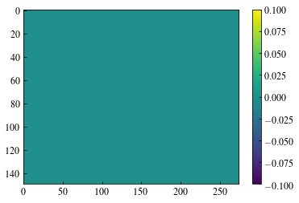

```python
fig, ax = plt.subplots()
iax = ax.imshow( mean_pixel_charge_f - mean_pixel_charge, aspect='auto' )
fig.colorbar(iax)
```

From the image, we see that both procedure reach the same output. Another way to check is also by sum up all differences, and check it is zero

```python
( mean_pixel_charge_f - mean_pixel_charge ).sum()
```

```
0.0
```

### 4.1 CompressSkipperImage

There is a process that does this operation of compressin the skippers to end with a single image of dimension 2: CompressSkipperImage. We will explore in more detail this class in the **How to Process for Analysis**.

Here an example of how to do it:

```python
comp = ccd.processes.skipper_analysis.CompressSkipperProcess()
```

```python
comp.info()
```

```
<CompressSkipsProcess> with sequence id 10.
 List of public data members:
	 * __sequence_id__ = 10
	 * __verbose__ = False
	 * func_to_compress = ['mean', 'std']
	 * id_col_end = nan
	 * id_col_start = nan
	 * id_row_end = nan
	 * id_row_start = nan
	 * id_skip_end = nan
	 * id_skip_start = nan
	 * image = raw
	 * save_image = False
	 * save_plots = False
```

With this process we can just limit the region of the skips to take into account. For each statiscal function listed on the attribute `func_to_compress` (statistic that must exist on `numpy`) a new image will be created and returned as a new attribute on the object `rdata`.

#### Let's see it with an example

Let's said we are only want to consider skip measurements from skip id 10 up to skip id 63, using only the `mean` function:

```python
comp.id_skip_start = 10
comp.id_skip_end = 63
comp.func_to_compress = ['mean']
```

Now we only need to execute this process on our data:

```python
comp.execute_process( rdata )
```

```
Process <CompressSkipsProcess> INFO. Compressing raw image data using the following statistics: ['mean']
     - used skip range 10:63
     - image (150, 275, 53) have been reduced to 150x275
```

This process return the compressed image as a new attribute on our data: `rdata.image_mean_compressed`

```python
rdata.image_mean_compressed.shape
```

```
(150, 275)
```

When object `mean_pixel_charge` was done, the full set of skips where used, but not here. In this example, the skippe compression process take into consideration only skip measurements from 10 to 63,

```python
(rdata.image_mean_compressed - mean_pixel_charge).sum()
```

```
652172.6813089622
```

To get the same results just consider all skips

```python
comp.id_skip_end = -1
comp.id_skip_start = 0
comp.execute_process(rdata)
```

```
Process <CompressSkipsProcess> INFO. Compressing raw image data using the following statistics: ['mean']
     - used skip range 0:64
     - image (150, 275, 64) have been reduced to 150x275
```

```python
(rdata.image_mean_compressed - mean_pixel_charge).sum()
```

```
0.0
```

And now we get the same result!

If you set the attribute `comp.__verbose__` you will get an ouptu image:

```python
comp.__verbose__
```

```
False
```

```
Process <CompressSkipsProcess> INFO. Compressing raw image data using the following statistics: ['mean']
     - used skip range 0:64
     - image (150, 275, 64) have been reduced to 150x275
```

```
/home/ncastello/.local/lib/python3.5/site-packages/matplotlib/figure.py:98: MatplotlibDeprecationWarning:
Adding an axes using the same arguments as a previous axes currently reuses the earlier instance.  In a future version, a new instance will always be created and returned.  Meanwhile, this warning can be suppressed, and the future behavior ensured, by passing a unique label to each axes instance.
  "Adding an axes using the same arguments as a previous axes "
```

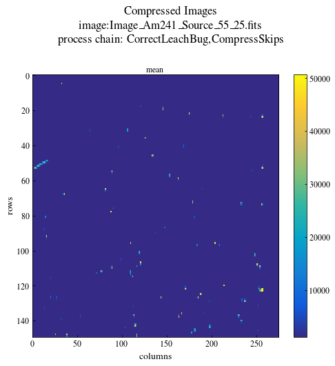

```python
comp.__verbose__ = True
comp.execute_process(rdata)
```

The warning is just because one of the used axis was re-used (not important right now, and will be removed in the next version of pysimdamicm)

## 5. Use of `RawData` for already compressed images

Up to now, we learn how to read our data properly using a configuration file. We have seen that the method used to load the image modifies its dimension to be an array of 3-dimensions: rows, cols and skips (in this order).

### What happen if the image we want to load has no skips (or is already a compressed one)?

The keyword on the fits file header `NCDMS` must point to 1 to properly load the data. So you can just change the parameter `cfg.configuration['input']['convention']['Nskips']` to point to a variable with value `int(1)`. If the image you use is the output of the previous process `CompressSkipperImage` you do not need to do nothing beause this is already done!

#### Let's see it.

For this, I will use an image that was compressed by using `CompressSkipperImage` and stored by this process too.

As before I will use a variable to define the path, and the patter for the fits file name. You can just use a single variable with the absolute path to the fits file (I am using that in case we want to play with other images from the same path).

```python
path_to_avgimg = "/data/workdir/compton/data/calidaq_backup/DataTaking/Am241/outputs/run027/avgimg"
patter_file_name = "Image_Am241_Source_27_{}_compressed.fits"

cfile_name = "{}/{}".format(path_to_avgimg,patter_file_name)
```

```python
cdata = ccd.io.rawdata.BuilderRawData(cfile_name.format(205),cfg.configuration['input'])
```

[output not shown]

[output cut: 44 more lines]

```
RDSTRT  = 'Mon Oct 26 23:04:29 2020' / Readout start time
RDEND   = 'Mon Oct 26 23:05:07 2020' / Readout end time
MEXP    =           3005.68657 / Measured exposure time (ms)
MREAD   =         37318.026539 / Measured readout time (ms)
NSKIPS  =                   64 / Number of charge measurements for the raw data
Summary:

N. rows=150 columns=275 skips=1
Image ndim:  2
Image shape: (150, 275)
Image size:  41250
Image dtype: >f8
Correction INFO. Correcting data for Leach bug:
 	 the first two column moved to the end,
 	 move one-row down (only the two last columns).
```

```python
cdata.image.shape
```

```
(150, 275)
```

The data is then a 2D ndarray.

Note that this time a new image has also been created:

`cdata.image_mean_compressed`

```python
cdata.image_mean_compressed.shape
```

```
(150, 275)
```

Both images, `image` and `image_mean_compressed` are the same:

```python
(cdata.image_mean_compressed - cdata.image).sum()
```

```
0.0
```

### What would happen if we wanted to compress that image?

```python
comp.execute_process(cdata)
```

```
Process <CompressSkipsProcess> INFO. Compressing raw image data using the following statistics: ['mean']
  WARNING. Number of skips = 1, nothing to do!
```

As we should expect!

The number of skips in the input fits file header (`NCDMS`) was changed to be 1. The data member `image_header` of the `RawData` object contains the header of the input fits file. Let's see the values for this variables

```python
print(repr(cdata.image_header))
```

```
SIMPLE  =                    T / conforms to FITS standard
BITPIX  =                  -64 / array data type
NAXIS   =                    2 / number of array dimensions
NAXIS1  =                  275
NAXIS2  =                  150
COMMENT   FITS (Flexible Image Transport System) format is defined in 'Astronomy
COMMENT   and Astrophysics', volume 376, page 359; bibcode: 2001A&A...376..359H
COMMENT This image was taken by a DAMIC UW CCD. The various settings used are st
COMMENT ored as keys in the FITS file.Processed by CCDDrone - Pitam Mitra @ UW.
COMMENT If you have questions, please send them to pitamm@uw.edu
CCDTYPE = 'SK      '           / CCD Type (DES or SK)
EXP     =                   3. / Exposure time (s)
NDCMS   =                    1 / Number of charge measurements
AMPL    = 'U       '           / Amplifier(s) used
COMMENT ASMFILE: Sequencer file used /home/Leach/CCDSequencer/firmware_super_seq
COMMENT uencer_Paolo_Aug2020_inverted.lod
SUPERSE =                    1 / Super sequencer (SSeq) used?
INVRG   =                    0 / Is RG inverted
HCKDIRN = 'U       '           / Serial register h-clock direction (SSEq only)
VCKDIRN = '1       '           / Vertical clock direction (SSeq only)
ITGTIME =                   5. / Integration time (SSeq only)
VIDGAIN =                    1 / Video gain
ITGSPD  =                    0 / Integrator speed (0=slow, 1=fast)
PRETIME =                  0.5 / Pedestal settling + video ADC refresh time
POSTIME =                  0.5 / Signal settling time
DGWIDTH =                 0.24 / DG Width (SK only)
RGWIDTH =                 0.24 / Reset width (SK only)
OGWIDTH =                 0.24 / OG Width (SK only)
SWWIDTH =                 0.24 / SW Pulse Width (SK only)
HWIDTH  =                 0.24 / H-Clock Width (SK only)
HOWIDTH =                 0.24 / H-Clock overlap Width (SK only)
VWIDTH  =                  20. / V-Clock Width (SK only)
VOWIDTH =                  20. / V-Clock overlap Width (SK only)
NPBIN   =                    4 / Binning in the V-direction (parallel clocks)
NSBIN   =                    4 / Binning in the H-direction (serial clocks)
SECSTG  = 'UW2     '           / Second stage board revision (SSeq only)
ONEVCKHI=                  1.5 / V1 clock Hi
ONEVCKLO=                 -0.5 / V1 clock Lo
TWOVCKHI=                  1.5 / V2 clock Hi
TWOVCKLO=                 -0.5 / V2 clock Lo
```

[output cut: 27 more lines]

```
VIDOFFL =                 2000 / Video pedestal offset L
VIDOFFU =                 2000 / Video pedestal offset U
DRAIN1  =                -24.5 / Drain1 (Relevant to SK)
DRAIN2  =                -24.5 / Drain2 (Relevant to SK)
VREF1   =                  -7. / VRef
VREF2   =                  -7. / VRef
OPG1    =                 2.21 / OpG1 (Relevant to DES)
OPG2    =                 2.21 / OpG2 (Relevant to DES)
PROGSTRT= 'Mon Oct 26 23:04:26 2020' / Program start time
EXPSTART= 'Mon Oct 26 23:04:26 2020' / Exposure start time
RDSTRT  = 'Mon Oct 26 23:04:29 2020' / Readout start time
RDEND   = 'Mon Oct 26 23:05:07 2020' / Readout end time
MEXP    =           3005.68657 / Measured exposure time (ms)
MREAD   =         37318.026539 / Measured readout time (ms)
NSKIPS  =                   64 / Number of charge measurements for the raw data
```

We can see here that the parameter 'NDCMS' is set to 1 and a new one has been included 'NSKIPS' pointing to the number of measurements of the original raw data.

Note that we did not change the configuration options, and 'Nskips' points to 'NDCMS' which now is set to 1, as should be.

## 6. Define CCD regions: over[pre]-scan and active regions

Up to now we learn how to load our data with the correct configuration options. By default when a `RawData` is created it only reads the header and the data from the fits files, and re-shape the data to properly diferenciate between rows, columns and skips (if necessary).

But, how do we access the different regions of the data? How to get only the overscan on rows? or the active region?

If the configuration options has the correct values for this regions you just need to run

```python
rdata.prepare_data()
```

```
RawData INFO.
 ********* Define mask for sensor and over/pre-scan regions 'Image_Am241_Source_55_25.fits' *********

 * Active region:
		rows=0:150
		cols=3:260

 * Overscan  in cols:
		rows=0:150
		cols=260:275

 * Prescan  in cols:
		rows=0:150
		cols=0:3

 * NO Overscan  in rows

 * NO Prescan in rows
 ***********************************************************************.
```

If the configuration options has not the correct one, and you do not want to re-load the data, you can just change the values on the `rdata` object.

### 6.1 Modify regions

Let's assume that the overscan on cols comprises the last 30 columns, instead of the 15 we have reported through the configuration options.

```python
rdata.n_cols_overscan
```

```
15
```

```python
rdata.n_cols_overscan = 30
rdata.n_cols_overscan
```

```
30
```

```python
rdata.prepare_data()
```

```
RawData INFO.
 ********* Define mask for sensor and over/pre-scan regions 'Image_Am241_Source_55_25.fits' *********

 * Active region:
		rows=0:150
		cols=3:245

 * Overscan  in cols:
		rows=0:150
		cols=245:275

 * Prescan  in cols:
		rows=0:150
		cols=0:3

 * NO Overscan  in rows

 * NO Prescan in rows
 ***********************************************************************.
```

### 6.2 Access to the different regions

This method create several atributes on the object `rdata` to properly point to the different regions. These are

- `mask_image_active_region`
- `mask_image_overscan_cols`
- `mask_image_overscan_rows`
- `mask_image_prescan_cols`
- `mask_image_prescan_rows`

```python
type(rdata.mask_image_prescan_cols)
rdata.mask_image_prescan_cols
```

```
array([[False, False, False, ...,  True,  True,  True],
       [False, False, False, ...,  True,  True,  True],
       [False, False, False, ...,  True,  True,  True],
       ...,
       [False, False, False, ...,  True,  True,  True],
       [False, False, False, ...,  True,  True,  True],
       [False, False, False, ...,  True,  True,  True]])
```

Internally when any function/process wants to access to some specific region of the CCD will create a `masked` numpy array uisng this boolean arrrays as mask.

##### Let's see that with a plot: plotting only the active region by using a [masked array from numpy](https://numpy.org/doc/stable/reference/maskedarray.generic.html).

```
 There are 4950 pixels that have been masked
```

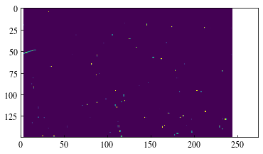

```python
plt.figure("sensitive region")
plt.imshow(np.ma.array( rdata.image_mean_compressed, mask= rdata.mask_image_active_region))
print( " There are {} pixels that have been masked".format(rdata.mask_image_active_region.sum()))
```

#### or only the overscan on columns

```
 There are 36750 pixels that have been masked
```

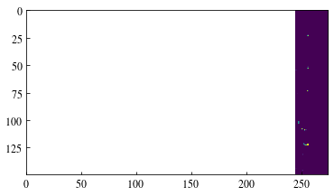

```python
plt.figure("overscan on cols")
plt.imshow(np.ma.array( rdata.image_mean_compressed, mask= rdata.mask_image_overscan_cols))
print( " There are {} pixels that have been masked".format(rdata.mask_image_overscan_cols.sum()))
```

#### Pay attention when use masked array for numerical operations:

Instead of using functions from the main package `numpy` is recomended to use the module `ma` from `numpy` (i.e. `numpy.ma`) to properly perorme any numerical operation without worrying about masked values.

#### How looks like a masked array ?

Let's display only the first row of the overscan masked image

```python
mimg = np.ma.array( rdata.image_mean_compressed, mask= rdata.mask_image_overscan_cols)

mimg[0,:]
```

```
masked_array(data=[--, --, --, --, --, --, --, --, --, --, --, --, --, --,
                   --, --, --, --, --, --, --, --, --, --, --, --, --, --,
                   --, --, --, --, --, --, --, --, --, --, --, --, --, --,
                   --, --, --, --, --, --, --, --, --, --, --, --, --, --,
                   --, --, --, --, --, --, --, --, --, --, --, --, --, --,
                   --, --, --, --, --, --, --, --, --, --, --, --, --, --,
                   --, --, --, --, --, --, --, --, --, --, --, --, --, --,
                   --, --, --, --, --, --, --, --, --, --, --, --, --, --,
                   --, --, --, --, --, --, --, --, --, --, --, --, --, --,
                   --, --, --, --, --, --, --, --, --, --, --, --, --, --,
                   --, --, --, --, --, --, --, --, --, --, --, --, --, --,
                   --, --, --, --, --, --, --, --, --, --, --, --, --, --,
                   --, --, --, --, --, --, --, --, --, --, --, --, --, --,
                   --, --, --, --, --, --, --, --, --, --, --, --, --, --,
                   --, --, --, --, --, --, --, --, --, --, --, --, --, --,
                   --, --, --, --, --, --, --, --, --, --, --, --, --, --,
                   --, --, --, --, --, --, --, --, --, --, --, --, --, --,
                   --, --, --, --, --, --, --, 1086.03125, 1078.09375,
                   1083.765625, 1079.875, 1086.484375, 1090.078125,
                   1084.859375, 1084.734375, 1087.421875, 1087.0, 1089.0,
                   1089.6875, 1084.875, 1085.078125, 1084.8125,
                   1091.21875, 1083.734375, 1090.796875, 1076.1875,
                   1085.71875, 1076.109375, 1079.546875, 1075.359375,
                   1087.140625, 1089.640625, 1085.4375, 1084.96875,
                   1081.453125, 1086.765625, 1085.8125],
             mask=[ True,  True,  True,  True,  True,  True,  True,  True,
                    True,  True,  True,  True,  True,  True,  True,  True,
                    True,  True,  True,  True,  True,  True,  True,  True,
                    True,  True,  True,  True,  True,  True,  True,  True,
                    True,  True,  True,  True,  True,  True,  True,  True,
                    True,  True,  True,  True,  True,  True,  True,  True,
                    True,  True,  True,  True,  True,  True,  True,  True,
                    True,  True,  True,  True,  True,  True,  True,  True,
                    True,  True,  True,  True,  True,  True,  True,  True,
                    True,  True,  True,  True,  True,  True,  True,  True,
                    True,  True,  True,  True,  True,  True,  True,  True,
                    True,  True,  True,  True,  True,  True,  True,  True,
                    True,  True,  True,  True,  True,  True,  True,  True,
                    True,  True,  True,  True,  True,  True,  True,  True,
                    True,  True,  True,  True,  True,  True,  True,  True,
                    True,  True,  True,  True,  True,  True,  True,  True,
                    True,  True,  True,  True,  True,  True,  True,  True,
                    True,  True,  True,  True,  True,  True,  True,  True,
                    True,  True,  True,  True,  True,  True,  True,  True,
                    True,  True,  True,  True,  True,  True,  True,  True,
                    True,  True,  True,  True,  True,  True,  True,  True,
                    True,  True,  True,  True,  True,  True,  True,  True,
                    True,  True,  True,  True,  True,  True,  True,  True,
                    True,  True,  True,  True,  True,  True,  True,  True,
                    True,  True,  True,  True,  True,  True,  True,  True,
                    True,  True,  True,  True,  True,  True,  True,  True,
                    True,  True,  True,  True,  True,  True,  True,  True,
                    True,  True,  True,  True,  True,  True,  True,  True,
                    True,  True,  True,  True,  True,  True,  True,  True,
                    True,  True,  True,  True,  True,  True,  True,  True,
                    True,  True,  True,  True,  True, False, False, False,
                   False, False, False, False, False, False, False, False,
                   False, False, False, False, False, False, False, False,
                   False, False, False, False, False, False, False, False,
                   False, False, False],
       fill_value=1e+20)
```

This object has two main attributes: data and mask. The data for those masked pixels appears as '--', and will not be used.

Despite it has part of the data masked, it still contain the original shape

```python
mimg.shape
```

```
(150, 275)
```

#### An example of numerical operations with masked arrays

```python
mimg**0.5
```

```
masked_array(
  data=[[--, --, --, ..., 32.885454611423576, 32.96612845027453,
         32.95166915347385],
        [--, --, --, ..., 32.95427703652441, 32.85051369461367,
         32.91537444720932],
        [--, --, --, ..., 32.90018047062964, 33.00307750801431,
         32.84099952802899],
        ...,
        [--, --, --, ..., 32.95238041477429, 32.88854283789417,
         32.890918199405746],
        [--, --, --, ..., 32.936966314461934, 32.94479283589442,
         32.965654475529526],
        [--, --, --, ..., 32.91489974160638, 32.95569943120613,
         32.875712920026544]],
  mask=[[ True,  True,  True, ..., False, False, False],
        [ True,  True,  True, ..., False, False, False],
        [ True,  True,  True, ..., False, False, False],
        ...,
        [ True,  True,  True, ..., False, False, False],
        [ True,  True,  True, ..., False, False, False],
        [ True,  True,  True, ..., False, False, False]],
  fill_value=1e+20)
```

#### Be careful with some statistics from numpy over masked array!

```python
np.mean( mimg )
```

```
1245.1978020833333
```

```python
np.median( mimg )
```

```
/home/ncastello/.local/lib/python3.5/site-packages/numpy/core/fromnumeric.py:746: UserWarning: Warning: 'partition' will ignore the 'mask' of the MaskedArray.
  a.partition(kth, axis=axis, kind=kind, order=order)
```

```
1083.296875
```

##### pointing to bad values

This warning tell us that function `np.median` is not taking into account the masked values, and we will get a non desired value for the median of our masked image. The proper way to operate with masked array is then by using the module `ma`, as already mentioned!

Wee see that some of the functions on `numpy` are override to work with masked arrays, but not all of them. So be really careful, and when the input array is masked just use `ma` functions instead of `numpy`.

```python
np.ma.median( mimg ) - np.median( mimg )
```

```
/home/ncastello/.local/lib/python3.5/site-packages/numpy/core/fromnumeric.py:746: UserWarning: Warning: 'partition' will ignore the 'mask' of the MaskedArray.
  a.partition(kth, axis=axis, kind=kind, order=order)
```

```
0.125
```

```python
np.mean(mimg) - mimg.mean()
```

```
0.0
```

```python
np.mean(mimg) - np.ma.mean(mimg)
```

```
0.0
```